# Introduction to Bioconductor Classes

12-16 June | CSAMA 2023

## Introduction

https://contributions.bioconductor.org/important-bioconductor-package-development-features.html#reusebioc

Common Bioconductor Classes

| Data Type | Package Name | Function |
| --- | --- | --- |
| Rectangular feature x sample data (RNAseq count matrix, microarray, …) | SummarizedExperiment | SummarizedExperiment() |
| Genomic coordinates (1-based, closed interval) | GenomicRanges | GRanges() or GRangesList() |
| Ragged genomic coordinates | RaggedExperiment | RaggedExperiment() |
| DNA / RNA / AA sequences | Biostrings | *StringSet() |
| Gene sets | BiocSet GSEABase | BiocSet() GeneSet() or GeneSetCollection() |
| Multi-omics data | MultiAssayExperiment | MultiAssayExperiment() |
| Single cell data | SingleCellExperiment | SingleCellExperiment() |
| Mass spec data | Spectra | Spectra() |
| File formats | BiocIO | BiocFile-class |

## Three Commonly Used or Extended Classes

- Biostrings::*StringSets
- GenomicRanges::GenomicRanges
- SummarizedExperiment::SummarizedExperiment

## Genomic Sequences

Biostrings

- *Valid* data, e.g., alphabet
- ‘Vector’ interface: `length()`, `[`, …
- Specialized operations, e.g,. `reverseComplement()`

Classes

- BString / BStringSet
- DNAString / DNAStringSet
- RNAString / RNAStringSet
- AAString / AAStringSet

## DNA Sequence Example

```r
library(Biostrings)

dna <- DNAStringSet(c("AAACTG", "CCCTTCAAC", "TACGAA"))
dna
```

```
## DNAStringSet object of length 3:
##     width seq
## [1]     6 AAACTG
## [2]     9 CCCTTCAAC
## [3]     6 TACGAA
```

```r
length(dna)
```

```
## [1] 3
```

```r
dna[c(1, 3, 1)]
```

```
## DNAStringSet object of length 3:
##     width seq
## [1]     6 AAACTG
## [2]     6 TACGAA
## [3]     6 AAACTG
```

## DNA Sequence Example cont.

```r
width(dna)
```

```
## [1] 6 9 6
```

```r
as.character(dna[c(1,2)])
```

```
## [1] "AAACTG"    "CCCTTCAAC"
```

```r
reverseComplement(dna)
```

```
## DNAStringSet object of length 3:
##     width seq
## [1]     6 CAGTTT
## [2]     9 GTTGAAGGG
## [3]     6 TTCGTA
```

[figure not shown]

## Importing Genomic Sequence

Import Methods from FASTA/FASTQ

- readBStringSet / readDNAStringSet / readRNAStringSet / readAAStringSet

```r
filepath1 <- system.file("extdata", "someORF.fa", package="Biostrings")
x1 <- readDNAStringSet(filepath1)
x1
```

```
## DNAStringSet object of length 7:
##     width seq                                               names
## [1]  5573 ACTTGTAAATATATCTTTTATTT...CTTATCGACCTTATTGTTGATAT YAL001C TFC3 SGDI...
## [2]  5825 TTCCAAGGCCGATGAATTCGACT...AGTAAATTTTTTTCTATTCTCTT YAL002W VPS8 SGDI...
## [3]  2987 CTTCATGTCAGCCTGCACTTCTG...TGGTACTCATGTAGCTGCCTCAT YAL003W EFB1 SGDI...
## [4]  3929 CACTCATATCGGGGGTCTTACTT...TGTCCCGAAACACGAAAAAGTAC YAL005C SSA1 SGDI...
## [5]  2648 AGAGAAAGAGTTTCACTTCTTGA...ATATAATTTATGTGTGAACATAG YAL007C ERP2 SGDI...
## [6]  2597 GTGTCCGGGCCTCGCAGGCGTTC...AAGTTTTGGCAGAATGTACTTTT YAL008W FUN14 SGD...
## [7]  2780 CAAGATAATGTCAAAGTTAGTGG...GCTAAGGAAGAAAAAAAAATCAC YAL009W SPO7 SGDI...
```

## Importing Genomic Sequences

Utilizing BSgenome Packages

BSgenome packages contain sequence information for a given species/build. There are many such packages - you can get a listing using `BiocManager::available("BSgenome")`

```r
library(BSgenome)
head(BiocManager::available("BSgenome"))
```

```
## [1] "BSgenome"
## [2] "BSgenome.Alyrata.JGI.v1"
## [3] "BSgenome.Amellifera.BeeBase.assembly4"
## [4] "BSgenome.Amellifera.NCBI.AmelHAv3.1"
## [5] "BSgenome.Amellifera.UCSC.apiMel2"
## [6] "BSgenome.Amellifera.UCSC.apiMel2.masked"
```

Can’t find what you are looking for? Check out the new BSgenomeForge for creating a BSgenome package.

## BSgenome

We can load and inspect a BSgenome package

```r
library(BSgenome.Hsapiens.UCSC.hg19)
BSgenome.Hsapiens.UCSC.hg19
```

```
## | BSgenome object for Human
## | - organism: Homo sapiens
## | - provider: UCSC
## | - genome: hg19
## | - release date: June 2013
## | - 298 sequence(s):
## |     chr1                  chr2                  chr3
## |     chr4                  chr5                  chr6
## |     chr7                  chr8                  chr9
## |     chr10                 chr11                 chr12
## |     chr13                 chr14                 chr15
## |     ...                   ...                   ...
## |     chr19_gl949749_alt    chr19_gl949750_alt    chr19_gl949751_alt
## |     chr19_gl949752_alt    chr19_gl949753_alt    chr20_gl383577_alt
## |     chr21_gl383578_alt    chr21_gl383579_alt    chr21_gl383580_alt
## |     chr21_gl383581_alt    chr22_gl383582_alt    chr22_gl383583_alt
## |     chr22_kb663609_alt
## | Tips: call 'seqnames()' on the object to get all the sequence names, call
## | 'seqinfo()' to get the full sequence info, use the '$' or '[[' operator to
## | access a given sequence, see '?BSgenome' for more information.
```

## Subsetting a BSgenome

The main accessor is `getSeq`, and you can get data by sequence (e.g., entire chromosome or unplaced scaffold), or by passing in a *GRanges* object, to get just a region.

```r
getSeq(BSgenome.Hsapiens.UCSC.hg19, "chr1")
```

```
## 249250621-letter DNAString object
## seq: NNNNNNNNNNNNNNNNNNNNNNNNNNNNNNNNNNNN...NNNNNNNNNNNNNNNNNNNNNNNNNNNNNNNNNNNN
```

```r
getSeq(BSgenome.Hsapiens.UCSC.hg19, GRanges("chr6:35310335-35395968"))
```

```
## DNAStringSet object of length 1:
##     width seq
## [1] 85634 GCGGAGCGTGTGACGCTGCGGCCGCCGCGGACCT...AATGGGAATTAAATATTTAAGAGCTGACTGGAA
```

## Genomic Ranges

GenomicRanges

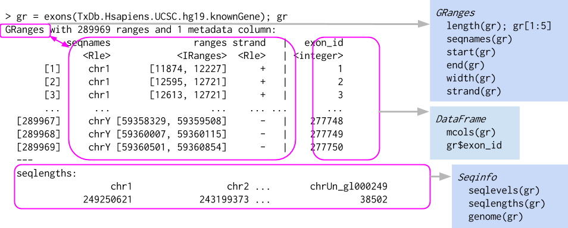

GenomicRanges objects allow for easy selection and subsection of data based on genomic position information.

## Where are GenomicRanges used?

Everywhere…

- Data (e.g., aligned reads, called peaks, copy number)
- Annotations (e.g., genes, exons, transcripts, TxDb)
- Close relation to BED files (see `rtracklayer::import.bed()` and HelloRanges)
- Anywhere there is Genomic positioning information

Utility

- Also vector interface – `length()`, `[`, etc.
- Tidyverse: plyranges

## GenomicRanges

```r
library(GenomicRanges)
gr <- GRanges(c("chr1:100-120", "chr1:115-130"))
gr
```

```
## GRanges object with 2 ranges and 0 metadata columns:
##       seqnames    ranges strand
##          <Rle> <IRanges>  <Rle>
##   [1]     chr1   100-120      *
##   [2]     chr1   115-130      *
##   -------
##   seqinfo: 1 sequence from an unspecified genome; no seqlengths
```

```r
gr <- GRanges(c("chr1:100-120", "chr1:115-130", "chr2:200-220"),
strand=c("+","+","-"), GC = seq(1, 0, length=3), id = paste0("id",1:3))
gr
```

```
## GRanges object with 3 ranges and 2 metadata columns:
##       seqnames    ranges strand |        GC          id
##          <Rle> <IRanges>  <Rle> | <numeric> <character>
##   [1]     chr1   100-120      + |       1.0         id1
##   [2]     chr1   115-130      + |       0.5         id2
##   [3]     chr2   200-220      - |       0.0         id3
##   -------
##   seqinfo: 2 sequences from an unspecified genome; no seqlengths
```

There are lots of utility functions for *GRange* objects

Help!

```r
methods(class="GRanges")
methods(class="GRangesList")
?"GRanges"
?"GRangesList"
```

## GRanges functions

Intra-range operations

- e.g., `shift()`, `narrow()`, `flank()`

Inter-range operations

- e.g., `reduce()`, `coverage()`, `gaps()`, `disjoin()`

Between-range operations

- e.g., `countOverlaps()`, `findOverlaps()`, `summarizeOverlaps()`

[figure not shown]

## GRanges Example

```r
shift(gr, 1)
```

```
## GRanges object with 3 ranges and 2 metadata columns:
##       seqnames    ranges strand |        GC          id
##          <Rle> <IRanges>  <Rle> | <numeric> <character>
##   [1]     chr1   101-121      + |       1.0         id1
##   [2]     chr1   116-131      + |       0.5         id2
##   [3]     chr2   201-221      - |       0.0         id3
##   -------
##   seqinfo: 2 sequences from an unspecified genome; no seqlengths
```

```r
reduce(gr)
```

```
## GRanges object with 2 ranges and 0 metadata columns:
##       seqnames    ranges strand
##          <Rle> <IRanges>  <Rle>
##   [1]     chr1   100-130      +
##   [2]     chr2   200-220      -
##   -------
##   seqinfo: 2 sequences from an unspecified genome; no seqlengths
```

```r
anno <- GRanges(c("chr1:110-150", "chr2:150-210"))
countOverlaps(anno, gr)
```

```
## [1] 2 1
```

## Lists of Genomic Ranges

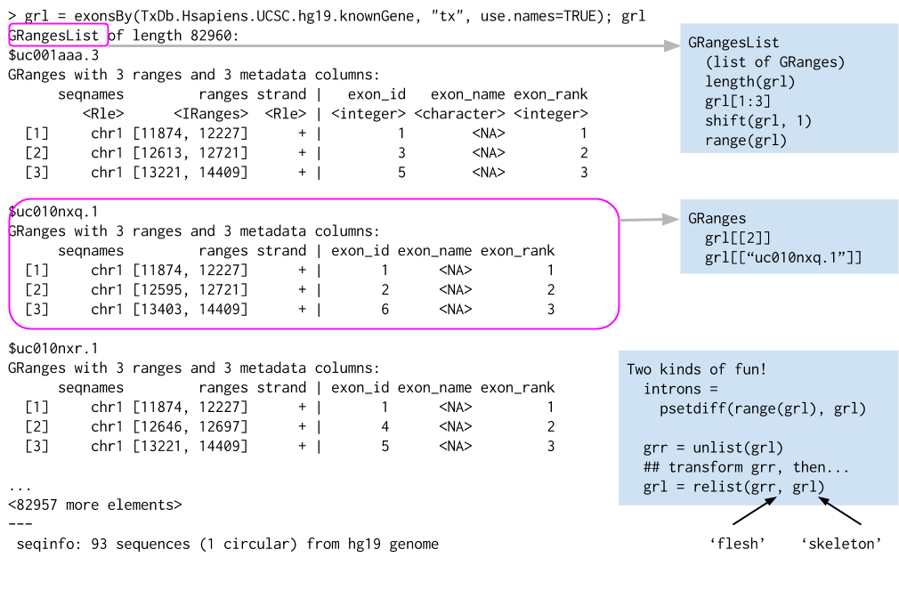

- e.g., exons-within-transcripts, alignments-within-reads

## More examples

Returning to BSGenome: Get the sequences for three UTR regions? `threeUTRsByTranscript()` returns a GRangesList

```r
library(TxDb.Hsapiens.UCSC.hg19.knownGene)
txdb <- TxDb.Hsapiens.UCSC.hg19.knownGene

threeUTR <-  threeUTRsByTranscript(txdb, use.names=TRUE)
threeUTR_seq <- extractTranscriptSeqs(Hsapiens, threeUTR)
options(showHeadLines = 3, showTailLines = 2)
threeUTR_seq
```

```
## DNAStringSet object of length 60740:
##         width seq                                           names
##     [1]   770 TGCCCGTTGGAGAAAACAGGG...AAAGCACACTGTTGGTTTCTG uc010nxq.1
##     [2]  1333 CTGTGAGGCCATTTCCAGGCC...GCCCCTCCCACGCGGACAGAG uc009vjk.2
##     [3]  2976 CTGTGAGGCCATTTCCAGGCC...AATGAAAAATATCGCCCACGA uc001aau.3
##     ...   ... ...
## [60739]  1191 GCACCCTGACCCTATTCAGCA...TATGGAATTTGTATTTAATAA uc011mgh.2
## [60740]  1191 GCACCCTGACCCTATTCAGCA...TATGGAATTTGTATTTAATAA uc011mgi.2
```

## More examples

How many genes are between 2858473 and 3271812 on chr2 in the hg19 genome?

```r
gns <- genes(txdb)
```

```
##   403 genes were dropped because they have exons located on both strands
##   of the same reference sequence or on more than one reference sequence,
##   so cannot be represented by a single genomic range.
##   Use 'single.strand.genes.only=FALSE' to get all the genes in a
##   GRangesList object, or use suppressMessages() to suppress this message.
```

```r
gns[gns %over%  GRanges("chr2:2858473-3271812")]
```

```
## GRanges object with 1 range and 1 metadata column:
##        seqnames          ranges strand |     gene_id
##           <Rle>       <IRanges>  <Rle> | <character>
##   7260     chr2 3192741-3381653      - |        7260
##   -------
##   seqinfo: 93 sequences (1 circular) from hg19 genome
```

```r
## OR

subsetByOverlaps(gns, GRanges("chr2:2858473-3271812"))
```

```
## GRanges object with 1 range and 1 metadata column:
##        seqnames          ranges strand |     gene_id
##           <Rle>       <IRanges>  <Rle> | <character>
##   7260     chr2 3192741-3381653      - |        7260
##   -------
##   seqinfo: 93 sequences (1 circular) from hg19 genome
```

## Importing a BED file

We said earlier, GRanges are closely related to bed files. Lets look at the example in the rtracklayer::import.bed help page:

```r
library(rtracklayer)
test_bed <- system.file(package = "rtracklayer", "tests", "test.bed")
test <- import(test_bed)
test
```

```
## UCSC track 'ItemRGBDemo'
## UCSCData object with 5 ranges and 5 metadata columns:
##       seqnames              ranges strand |        name     score     itemRgb
##          <Rle>           <IRanges>  <Rle> | <character> <numeric> <character>
##   [1]     chr7 127471197-127472363      + |        Pos1         0     #FF0000
##   [2]     chr7 127472364-127473530      + |        Pos2         2     #FF0000
##   [3]     chr7 127473531-127474697      - |        Neg1         0     #FF0000
##   [4]     chr9 127474698-127475864      + |        Pos3         5     #FF0000
##   [5]     chr9 127475865-127477031      - |        Neg2         5     #0000FF
##                     thick                  blocks
##                 <IRanges>           <IRangesList>
##   [1] 127471197-127472363 1-300,501-700,1068-1167
##   [2] 127472364-127473530          1-250,668-1167
##   [3] 127473531-127474697                  1-1167
##   [4] 127474698-127475864                  1-1167
##   [5] 127475865-127477031                  1-1167
##   -------
##   seqinfo: 2 sequences from an unspecified genome; no seqlengths
```

## Bed file continued

In fact this class *Extends* the GenomicRange GRange class

```r
is(test, "GRanges")
```

```
## [1] TRUE
```

So you can use GRange functions

```r
subsetByOverlaps(test, GRanges("chr7:127471197-127472368"))
```

```
## UCSC track 'ItemRGBDemo'
## UCSCData object with 2 ranges and 5 metadata columns:
##       seqnames              ranges strand |        name     score     itemRgb
##          <Rle>           <IRanges>  <Rle> | <character> <numeric> <character>
##   [1]     chr7 127471197-127472363      + |        Pos1         0     #FF0000
##   [2]     chr7 127472364-127473530      + |        Pos2         2     #FF0000
##                     thick                  blocks
##                 <IRanges>           <IRangesList>
##   [1] 127471197-127472363 1-300,501-700,1068-1167
##   [2] 127472364-127473530          1-250,668-1167
##   -------
##   seqinfo: 2 sequences from an unspecified genome; no seqlengths
```

## Side Note:

Utilizing Bioconductor recommended import/export methods, classes, etc. has other benefits as well…

BED files have 0-based half-open intervals (left end point included, right endpoint ‘after’ the end of the range),

whereas in other parts of the bioinformatic community and in bioc the coordinates are 1-based and closed

Using `import()` converts BED coordinates into bioc coordinates.

## Working with BAM files

```r
library(GenomicAlignments)
fls <- list.files(system.file("extdata", package="GenomicAlignments"),
                  recursive=TRUE, pattern="*bam$", full=TRUE)
names(fls) <- basename(fls)
bf <- BamFileList(fls, index=character(), yieldSize=1000)
genes <- GRanges(
    seqnames = rep(c("chr2L", "chr2R", "chr3L"), c(4, 5, 2)),
    ranges = IRanges(c(1000, 3000, 4000, 7000, 2000, 3000, 3600,
                       4000, 7500, 5000, 5400),
                     width=c(rep(500, 3), 600, 900, 500, 300, 900,
                             300, 500, 500)))
se <- summarizeOverlaps(genes, bf)
se
```

```
## class: RangedSummarizedExperiment
## dim: 11 2
## metadata(0):
## assays(1): counts
## rownames: NULL
## rowData names(0):
## colnames(2): sm_treated1.bam sm_untreated1.bam
## colData names(0):
```

```r
# Start differential expression analysis with the DESeq2 or edgeR
```

## Summarized Experiments

SummarizedExperiment objects are popular objects for representing expression data and other rectangular data (feature x sample data). Incoming packages are now strongly recommended to use this class representation instead of ExpressionSet.

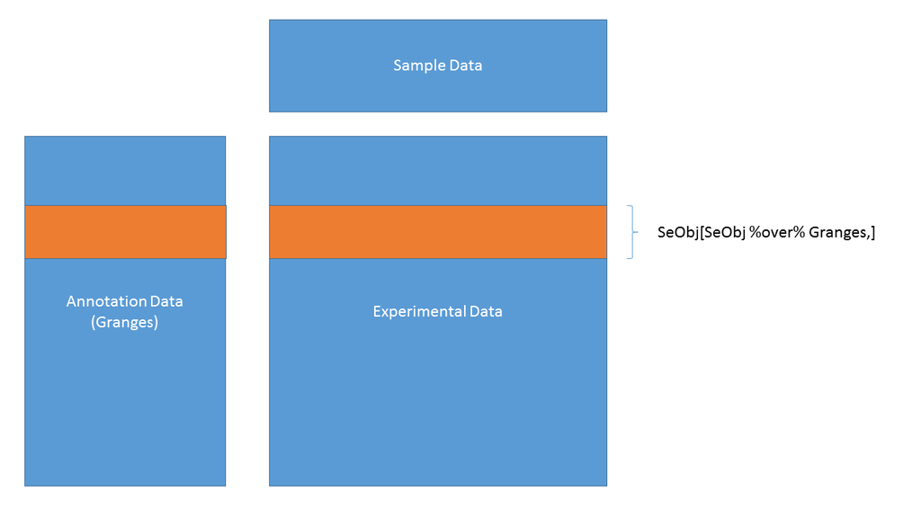

three components: underlying ‘matrix’ ‘row’ annotations (genomic features) ‘column’ annotations (sample descriptions)

## Summarized Experiments

## Components 1.

Main matrix of values / count data / expression values / etc …

```r
counts <- as.matrix(read.csv("lecture-01-data/airway_counts.csv", row.names=1))
head(counts, 3)
```

```
##                 SRR1039508 SRR1039509 SRR1039512 SRR1039513 SRR1039516
## ENSG00000000003        679        448        873        408       1138
## ENSG00000000419        467        515        621        365        587
## ENSG00000000457        260        211        263        164        245
##                 SRR1039517 SRR1039520 SRR1039521
## ENSG00000000003       1047        770        572
## ENSG00000000419        799        417        508
## ENSG00000000457        331        233        229
```

## Component 2.

Sample data / Phenotypic data / Sample specific information / etc …

```r
colData <- read.csv("lecture-01-data/airway_colData.csv", row.names=1)
colData[, 1:4]
```

```
##            SampleName    cell   dex albut
## SRR1039508 GSM1275862  N61311 untrt untrt
## SRR1039509 GSM1275863  N61311   trt untrt
## SRR1039512 GSM1275866 N052611 untrt untrt
## SRR1039513 GSM1275867 N052611   trt untrt
## SRR1039516 GSM1275870 N080611 untrt untrt
## SRR1039517 GSM1275871 N080611   trt untrt
## SRR1039520 GSM1275874 N061011 untrt untrt
## SRR1039521 GSM1275875 N061011   trt untrt
```

## Component 3.

Genomic position information / Information about features / etc …

```r
rowRanges <- updateObject(readRDS("lecture-01-data/airway_rowRanges.rds"))
options(showHeadLines = 3, showTailLines = 2)
rowRanges
```

```
## GRangesList object of length 33469:
## $ENSG00000000003
## GRanges object with 17 ranges and 2 metadata columns:
##        seqnames            ranges strand |   exon_id       exon_name
##           <Rle>         <IRanges>  <Rle> | <integer>     <character>
##    [1]        X 99883667-99884983      - |    667145 ENSE00001459322
##    [2]        X 99885756-99885863      - |    667146 ENSE00000868868
##    [3]        X 99887482-99887565      - |    667147 ENSE00000401072
##    ...      ...               ...    ... .       ...             ...
##   [16]        X 99891790-99892101      - |    667160 ENSE00001863395
##   [17]        X 99894942-99894988      - |    667161 ENSE00001828996
##   -------
##   seqinfo: 722 sequences (1 circular) from an unspecified genome
##
## ...
## <33468 more elements>
```

## Benefit of Containers

Could manipulate independently…

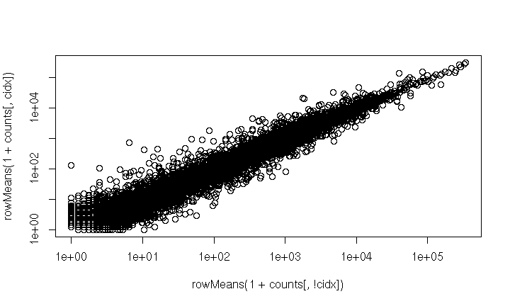

```r
cidx <- colData$dex == "trt"
plot(
    rowMeans(1 + counts[, cidx]) ~ rowMeans(1 + counts[, !cidx]),
    log="xy"
)
```

- very fragile, e.g., what if `colData` rows had been re-ordered?

## SummarizedExperiment

Solution: coordinate in a single object – SummarizedExperiment

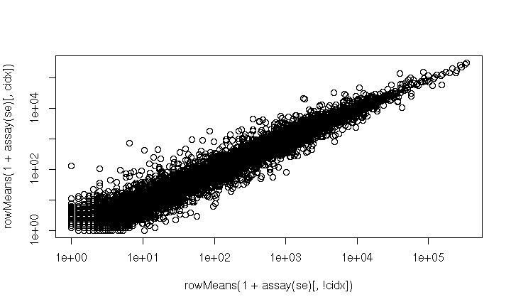

```r
library(SummarizedExperiment)

se <- SummarizedExperiment(counts, rowRanges = rowRanges, colData = colData)
cidx <- se$dex == "trt"
plot(
    rowMeans(1 + assay(se)[, cidx]) ~ rowMeans(1 + assay(se)[, !cidx]),
    log="xy"
)
```

## Benefits

- Much more robust to ‘bookkeeping’ errors
- matrix-like interface: `dim()`, two-dimensional `[`, …
- accessors: `assay()`, `rowData()` / `rowRanges()`, `colData()`, …

```r
dim(se)
```

```
## [1] 33469     8
```

```r
colnames(se[1:2,3:4])
```

```
## [1] "SRR1039512" "SRR1039513"
```

```r
names(colData)
```

```
## [1] "SampleName" "cell"       "dex"        "albut"      "Run"
## [6] "avgLength"  "Experiment" "Sample"     "BioSample"
```

## Popular

Many package make use of or extend the ideas of SummarizedExperiment

- SingleCellExpeirment
- TimeSeriesExperiment
- LoomExperiment
- TreeSummarizedExperiment
- MultiAssayExperiment

[figure not shown]

[figure not shown]

[figure not shown]

## Help

In R:

```r
methods(class="SummarizedExperiment")
?"SummarizedExperiment"
browseVignettes(package="SummarizedExperiment")
```

- Support site, https://support.bioconductor.org
- Bioc-devel, bioc-devel@r-project.org

Website: https://bioconductor.org

[figure not shown]